# Nagata_PyProject

Python Project - Marvel Mart Project

Nicole Nagata

March 15, 2023

```python
#importing libraries
import csv
import pandas as pd
import seaborn as sns
import matplotlib.pyplot as plt
pd.set_option('display.float_format', lambda x: '%.3f' % x)
```

Part 1: Cleaning the data

```python
#Data Exploration

sales = pd.read_csv('Data/MM_Sales.csv') #MM_Sales.csv into a data frame called 'sales'

salesNA = sales.isna().sum() #returns values for columns with missing data
print(salesNA)
```

```
Region             0
Country            0
Item Type          6
Sales Channel      0
Order Priority    15
Order Date         0
Order ID           0
Ship Date          0
Units Sold         0
Unit Price         0
Unit Cost          0
Total Revenue      0
Total Cost         0
Total Profit       0
dtype: int64
```

*If column has msising values, no need to test for further incorrect values

Country: need to test for incorrect values

Item Type: *6 missing values

Order Priority: *15 missing values

Order ID: need to test for incorrect values

```python
#creating a copy of sales data frame to modify as the 'clean' version
salesClean = sales.copy()
```

```python
#Testing 'Country' column for incorrect values

count = 0
print("\nTesting erronous data in Country")

for index, row in salesClean.iterrows():

    #try to convert the string to a float, if sucessful not a Country
    #turn float into NULL and add to the erronous data count
    try:
        row.loc['Country'] = float(row.loc['Country'])
        print(salesClean.loc[int(index), 'Country'])
        salesClean.loc[int(index), 'Country'] = "NULL"
        count += 1

    except:
        count += 0

print(f"Number of erronous countries {count}.")
```

```
Testing erronous data in Country
154.06
437.2
651.21
Number of erronous countries 3.
```

```python
#Testing 'Order ID' columns for incorrect values

count = 0
print("\nTesting erronous data in Order ID")

for index, row in salesClean.iterrows():

    #try to convert number into a float
    #if fails, not an accepted Order ID so turn to zero
    try:
        row.loc['Order ID'] = float(row.loc['Order ID'])
    except:
        print(row.loc['Order ID'])
        salesClean.loc[int(index), 'Order ID'] = 0
        count += 1

print(f"Number of eronous Order ID {count}.")
```

```
Testing erronous data in Order ID
Cosmetics
Fruits
Snacks
Meat
Snacks
Number of eronous Order ID 5.
```

```python
#remove rows that have incorrect data
salesClean = salesClean.dropna(axis = 0) #removes all rows with missing data from 'Item Type' and 'Order Priority'
salesClean = salesClean[salesClean['Country'] != "NULL"] #removes all rows with incorrect 'Country' that was changed to NULL
salesClean = salesClean[salesClean['Order ID'] != 0] #removed all rows with incorrect "Order ID' that was changed to a 0
```

```python
#testing that all rows are cleaned

#counting all incorrect values (NULL or 0) in columns, returning a 0 means data is cleaned
print(salesClean['Country'][salesClean['Country'] == "NULL"].count())
print(salesClean['Item Type'][salesClean['Item Type'] == None].count())
print(salesClean['Order Priority'][salesClean['Order Priority'] == None].count())
print(salesClean['Order ID'][salesClean['Order ID'] == "0"].count())
```

```
0
0
0
0
```

```python
#saving data to 'Data' folder as  MM_Sales_clean.csv
salesClean.to_csv("Data/MM_Sales_clean.csv")
salesClean = pd.read_csv("Data/MM_Sales_clean.csv")
```

Part 2: Exploratory Data Analysis

1. Country Rankings

# 1.1

```python
#rank top 10 Counrties by Sales Transactions

print("Top 10 Countries by Sales Transactions:\n")

salesTop10 = salesClean['Country'].value_counts() #count the rows by Countries (each row is one transaction)
display(salesTop10.head(10))
```

```
Top 10 Countries by Sales Transactions:
```

```
Trinidad and Tobago                 321
Guinea                              318
Cape Verde                          314
Maldives                            311
Finland                             310
Democratic Republic of the Congo    308
Samoa                               306
Malta                               305
China                               303
South Sudan                         302
Name: Country, dtype: int64
```

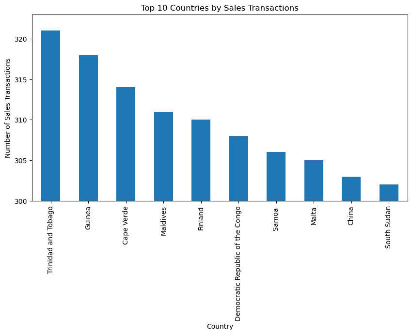

```python
#creates bar graph of the Top 10 countries by sales transactions

plt.figure(figsize=(10,5))

salesTop10.head(10).plot(kind='bar')
plt.title('Top 10 Countries by Sales Transactions')
plt.xlabel('Country')
plt.ylabel('Number of Sales Transactions')
plt.ylim(300,323) #y axis limit set to show difference is sales transactions better
plt.show()
```

This bar graph shows Marvel Mart's top ten countries by sales transactions. As seen along the y axis, all ten countries are very close in amount of sales transactions with a range of about twenty transactions. All of these countries should be a big focus to Marvel Mart, especially when deciding where to establish new shipping centers.

# 1.2

```python
#turns country ranking into a dictionary, to be automatically updated in the FOR loop
series = salesTop10.head(10)
series.to_dict()

#creating a new text file called MM_Rankings, and writing a header
with open("Data/MM_Rankings.txt", "w+") as writer:
    writer.write("Countries Most Sale Transactions: \n")

#appending top 10 countries and respective sales transactions to file
#also writing out answer
with open("Data/MM_Rankings.txt", "a") as writer:
    for k,v in series.items():
        writer.write(f'{k}: {v}\n')

    writer.write('\nThe country we should build our shipping center is Cape Verde because it is the highest ranking country, that we dont yet have a shipping center in.\n')

#reading file and printing its contents
with open("Data/MM_Rankings.txt", "r") as reader:
    print(reader.read())
```

```
Countries Most Sale Transactions:
Trinidad and Tobago: 321
Guinea: 318
Cape Verde: 314
Maldives: 311
Finland: 310
Democratic Republic of the Congo: 308
Samoa : 306
Malta: 305
China: 303
South Sudan: 302

The country we should build our shipping center is Cape Verde because it is the highest ranking country, that we dont yet have a shipping center in.
```

1. Count of Sales Channels & Order Priorities

# 2.1

```python
#counting online and offline orders

salesChannel = salesClean['Sales Channel'].value_counts() #count the rows by Countries (each row is one transaction)
display(salesChannel)

"""There are more online orders than offline orders"""
```

```
Online     30183
Offline    19788
Name: Sales Channel, dtype: int64
```

```
'There are more online orders than offline orders'
```

# 2.2

```python
#counting orders for different Order Priority types

salesPriority = salesClean['Order Priority'].value_counts() #count the rows by Countries (each row is one transaction)
display(salesPriority)

"""There are more Medium and High priority orders than Low and Critical priority orders."""
```

```
M    19881
H    15094
L     9984
C     5012
Name: Order Priority, dtype: int64
```

```
'There are more Medium and High priority orders than Low and Critical priority orders.'
```

# 2.3

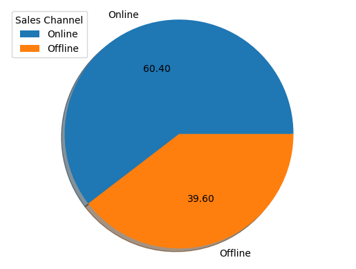

```python
#creating a pie chart for online and offline orders

plt.figure()
plt.pie(salesChannel, labels=salesChannel.index, shadow=True, autopct='%.2f')
plt.axis('equal')
plt.legend(loc=2, title='Sales Channel')
plt.show()
```

This pie chart shows the distribution of online and offline orders. Marvel Mart conducts more online orders, with a ratio of about a sixty percent online to fourty percent offline orders. Knowing that they conduct more online orders, Marvel Mart may want to shift their marketing towards offline orders. Getting more customers to order in-store will better profit their in house locations.

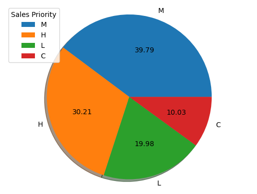

```python
#creating a pie chart for different types of order priorities

plt.figure()
plt.pie(salesPriority, labels=salesPriority.index, shadow=True, autopct='%.2f')
plt.axis('equal')
plt.legend(loc=2, title='Sales Priority')
plt.show()
```

This pie chart shows the distribution of differnet order priotirty types. Medium priority is the highest, taking about fourty percent of all orders. High priority is a close second at about thirty percent. Low and critical are the lowest with twenty and ten percent respectively. Marvel Mart should prioritize medium and high priority orders, knowing that these orders make up a large portion (well over sixity percent) of all their orders.

# 2.4

```python
#turning salesChennel and salesPriority into a dictionary
salesChannel.to_dict()
salesPriority.to_dict()

#appending sales channel count to MM_Rankings
with open("Data/MM_Rankings.txt", "a", newline="") as writer:
    writer.write("\nSales Channels: \n")

    for k,v in salesChannel.items():
        writer.write(f'{k}: {v}\n')

    writer.write('We do more online sales.\n')

#appending order priority count to MM_Rankings
with open("Data/MM_Rankings.txt", "a", newline="") as writer:
    writer.write("\nOrder Priorities: \n")

    for k,v in salesPriority.items():
        writer.write(f'{k}: {v}\n')

    writer.write('We do more medium order priorities.\n')

#reading MM_Rankings and printing its contents
with open("Data/MM_Rankings.txt", "r") as reader:
    print(reader.read())
```

```
Countries Most Sale Transactions:
Trinidad and Tobago: 321
Guinea: 318
Cape Verde: 314
Maldives: 311
Finland: 310
Democratic Republic of the Congo: 308
Samoa : 306
Malta: 305
China: 303
South Sudan: 302

The country we should build our shipping center is Cape Verde because it is the highest ranking country, that we dont yet have a shipping center in.

Sales Channels:
Online: 30183
Offline: 19788
We do more online sales.

Order Priorities:
M: 19881
H: 15094
L: 9984
C: 5012
We do more medium order priorities.
```

1. Profits by Item Type

# 3.1

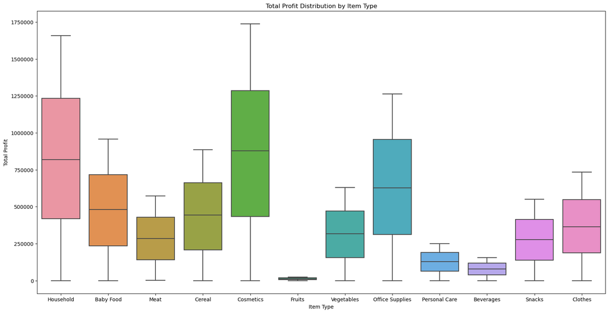

```python
#Create a Boxplot using Seaborn showing the Total Profits DISTRIBUTION by Item Type.

#create boxplot
plt.figure(figsize=(20,10))
sns.boxplot(x='Item Type', y='Total Profit', data=salesClean)
plt.title("Total Profit Distribution by Item Type")
plt.ticklabel_format(style='plain', axis='y')
plt.show()
```

This boxplot shows the total profit distribution by item type. Household, cosmetics, and office supplies bring in some of the highest average total profits, with fruits, beverages, and personal care items brining in the least total profit. In relatively all item types, the data does not seem to be skewed, nor are there any outliers. This data can be useful in knowing which products are most profitable, and which products need to be imporved or dropped from the line.

# 3.2

```python
#group data by 'Item Type' and calculate sum

profit_by_item = salesClean.groupby('Item Type')['Total Profit'].sum().sort_values(ascending=False)
pd.options.display.float_format = '{:.2f}'.format #changes output from scientific noation to decimal format
print(profit_by_item)
```

```
Item Type
Cosmetics         3638407966.75
Household         3401180998.06
Office Supplies   2605440187.50
Baby Food         1942865748.12
Cereal            1824726412.29
Clothes           1520832019.68
Vegetables        1322639660.24
Meat              1196342404.40
Snacks            1149715758.72
Personal Care      535250525.60
Beverages          327559249.08
Fruits              51010570.92
Name: Total Profit, dtype: float64
```

# 3.3

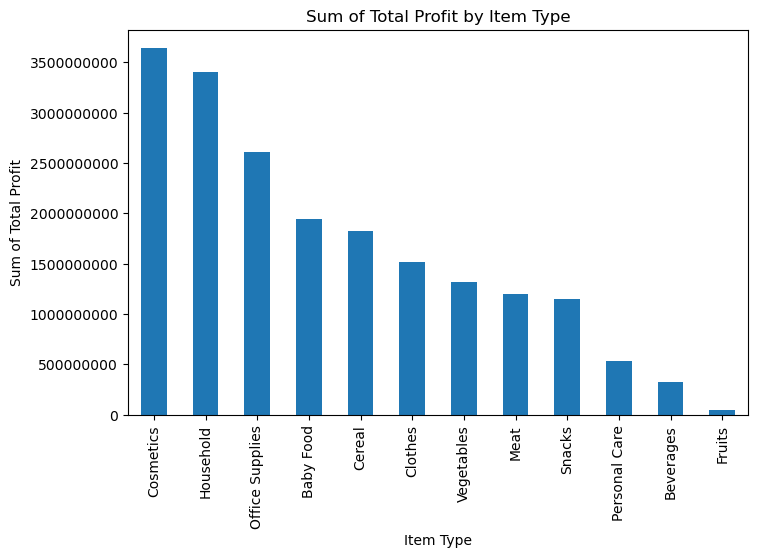

```python
#creates a bar graph of the sum of total profit by item type

plt.figure(figsize=(8,5))

profit_by_item.plot(kind='bar')
plt.title('Sum of Total Profit by Item Type')
plt.xlabel('Item Type')
plt.ylabel('Sum of Total Profit')
plt.ticklabel_format(style='plain', axis='y') #getting rid of scientific notation
plt.show()
```

This bar graph is a visual showing the sum of total profit by item type. Similarly to the boxplot, this graph shows that cosmetics, household, and office supplies bring in the most total profit, whereas fruits, beverages, and personal care bring in the least. This graph confirms that the products that make more profit on average, also make the most total profit overall. This visual can also help in deciding which products are most profitable, and which are not profitable.

# 3.4

```python
#ranking top 3 item types with the most sales

top3 = salesClean.groupby('Item Type')['Total Profit'].sum().nlargest(3)
print(top3)
```

```
Item Type
Cosmetics         3638407966.75
Household         3401180998.06
Office Supplies   2605440187.50
Name: Total Profit, dtype: float64
```

# 3.5

```python
#turning top 3 item types into a dictionary
top3.to_dict()

#appending top 3 item types to MM_Rankings
with open("Data/MM_Rankings.txt", "a", newline="") as writer:
    writer.write("\nHighest Selling Items: \n")

    for k,v in top3.items():
        writer.write(f'{k}: {v}\n')

    writer.write('We profited from Cosmetics the most.\n')

#reading MM_Rankings and printing its contents
with open("Data/MM_Rankings.txt", "r") as reader:
    print(reader.read())
```

```
Countries Most Sale Transactions:
Trinidad and Tobago: 321
Guinea: 318
Cape Verde: 314
Maldives: 311
Finland: 310
Democratic Republic of the Congo: 308
Samoa : 306
Malta: 305
China: 303
South Sudan: 302

The country we should build our shipping center is Cape Verde because it is the highest ranking country, that we dont yet have a shipping center in.

Sales Channels:
Online: 30183
Offline: 19788
We do more online sales.

Order Priorities:
M: 19881
H: 15094
L: 9984
C: 5012
We do more medium order priorities.

Highest Selling Items:
Cosmetics: 3638407966.75
Household: 3401180998.06
Office Supplies: 2605440187.5
We profited from Cosmetics the most.
```

# 3.6

The boxplot shows Marvel Mart's total profit distribution by item type. The graph shows that on average, household, cosmetics, and office supplies have the highest total profit, whereas fruits, beverages and personal care have the lowest. Among all item types, we can tell that the data is not skewed because the line separating the boxes are all relatively even. We can also tell there are no outliers because no extraneous points lie beyond the wiskers.

Looking at the profit distributions by item type will help Marvel Mart determine which products are profitable and which ones are not. Marvel Mart might consider dropping fruit products becuase it does not nearly bring in as much profit as the other ityem types. This will help Marvel Mart invest their money towards only profitable products, or work towards imporving lower profitability items.

4: Descprtive Statistics

# 4.1

```python
#creating variables to shorten column name
us = salesClean['Units Sold']
uc = salesClean['Unit Cost']
tr = salesClean['Total Revenue']
tc = salesClean['Total Cost']
tp = salesClean['Total Profit']
```

```python
#sums of each respective column
unitSoldSum = us.sum()
unitCostSum = uc.sum()
totalRevenueSum = tr.sum()
totalCostSum = tc.sum()
totalProfitSum = tp.sum()

#saving into dictionary
Sums = {
    "Units Sold": unitSoldSum,
    "Unit Cost": unitCostSum,
    "Total Revenue": totalRevenueSum,
    "Total Cost": totalCostSum,
    "Total Profit": totalProfitSum}

#printing sums
for k,v in Sums.items():
    print(f"Sum of {k}: {v}")
```

```
Sum of Units Sold: 249818150
Sum of Unit Cost: 9360768.320000002
Sum of Total Revenue: 66145004417.17
Sum of Total Cost: 46629032915.81
Sum of Total Profit: 19515971501.36
```

# 4.2

```python
#saving averages into dictionary
Avgs = {
    "Units Sold": us.mean(),
    "Unit Cost": uc.mean(),
    "Total Revenue": tr.mean(),
    "Total Cost": tc.mean(),
    "Total Profit": tp.mean()}

#printing averages
for k,v in Avgs.items():
    print(f"Average {k}: {v}")
```

```
Average Units Sold: 4999.262572291929
Average Unit Cost: 187.32401432829784
Average Total Revenue: 1323667.8156764843
Average Total Cost: 933121.8690002197
Average Total Profit: 390545.94667627424
```

# 4.3

```python
#saving maximums into a dictionary
Max = {
    "Units Sold": us.max(),
    "Unit Cost": uc.max(),
    "Total Revenue": tr.max(),
    "Total Cost": tc.max(),
    "Total Profit": tp.max()}

#printing maximums
for k,v in Max.items():
    print(f"Maximum {k}: {v}")
```

```
Maximum Units Sold: 10000
Maximum Unit Cost: 524.96
Maximum Total Revenue: 6682031.73
Maximum Total Cost: 5249075.04
Maximum Total Profit: 1738178.39
```

# 4.4

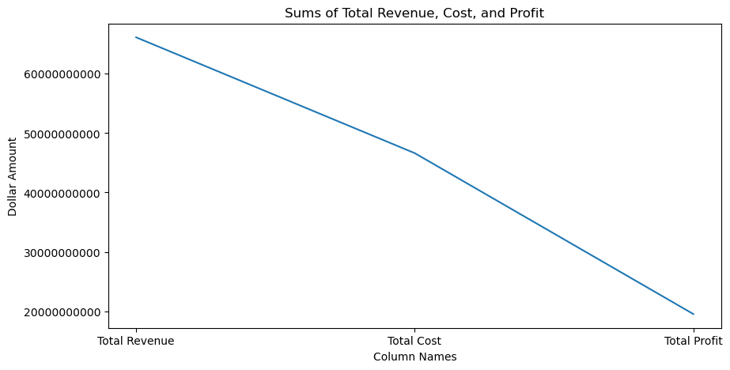

```python
#lineplot showing the sums of Total Revenue, Cost, and Profit
plt.figure(figsize=(10,5))
plt.plot(['Total Revenue', 'Total Cost', 'Total Profit'], [tr.sum(), tc.sum(), tp.sum()])
plt.title("Sums of Total Revenue, Cost, and Profit")
plt.xlabel("Column Names")
plt.ylabel("Dollar Amount")
plt.ticklabel_format(style='plain', axis='y')
plt.show()
```

This line plot shows the sums of the Total Revenue, Total Cost, and Total Profit. Marvel Mart has a Total Revenue that is higher than Total Cost, which is a good thing. This means that they will make a positive total profit, which is also shown in the graph above. Marvel Mart could use a line plot like this to track the ratio between their revenues, costs, and profits going forward.

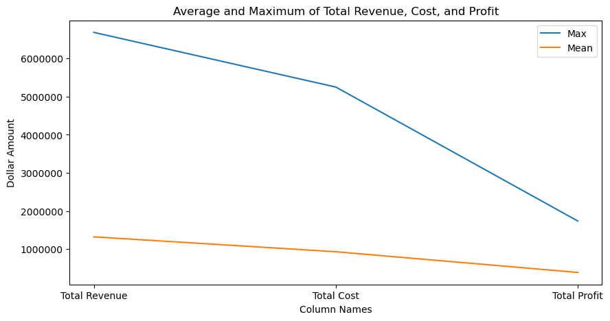

```python
#lineplot showing the average and maximum for respective columns

plt.figure(figsize=(10,5))
plt.plot(['Total Revenue', 'Total Cost', 'Total Profit'], [tr.max(), tc.max(), tp.max()], label='Max')
plt.plot(['Total Revenue', 'Total Cost', 'Total Profit'], [tr.mean(), tc.mean(), tp.mean()], label='Mean')
plt.title("Average and Maximum of Total Revenue, Cost, and Profit")
plt.legend()
plt.xlabel("Column Names")
plt.ylabel("Dollar Amount")
plt.ticklabel_format(style='plain', axis='y')
plt.show()
```

This line plot shows both the maximum and the average values of Marvel Mart's total revenue, cost, and profit. Similarly to the line plot above, total revenue will ideally have a higher average and maximum than total cost. This will result in a positive total profit in both average and maximum values, as seen in the line plot above.

# 4.5

```python
#creating a new file called MM_Calc.txt and listing sums
with open("Data/MM_Calc.txt", "w+", newline="") as writer:
    writer.write("Sums: \n")

    for k,v in Sums.items():
        writer.write(f'{k}: {v}\n')

#appending averages to MM_Calc
with open("Data/MM_Calc.txt", "a", newline="") as writer:
    writer.write("\nAverages: \n")

    for k,v in Avgs.items():
        writer.write(f'{k}: {v}\n')

#appending maximums to MM_Calc
with open("Data/MM_Calc.txt", "a", newline="") as writer:
    writer.write("\nMaximums: \n")

    for k,v in Max.items():
        writer.write(f'{k}: {v}\n')

#reading MM_Rankings and printing its contents
with open("Data/MM_Calc.txt", "r") as reader:
    print(reader.read())
```

```
Sums:
Units Sold: 249818150
Unit Cost: 9360768.320000002
Total Revenue: 66145004417.17
Total Cost: 46629032915.81
Total Profit: 19515971501.36

Averages:
Units Sold: 4999.262572291929
Unit Cost: 187.32401432829784
Total Revenue: 1323667.8156764843
Total Cost: 933121.8690002197
Total Profit: 390545.94667627424

Maximums:
Units Sold: 10000
Unit Cost: 524.96
Total Revenue: 6682031.73
Total Cost: 5249075.04
Total Profit: 1738178.39
```

Part 3: Cross-Reference Statistics

# 1.1

```python
Region = list(set(salesClean['Region']))

countriesByRegion = {}

#loop through "Region' column and get unique 'Country'
for x in Region:
    countries = salesClean.loc[salesClean['Region'] == x, 'Country']
    countries = list(set(countries)) #removes duplicates, if any
    countriesByRegion[x] = countries

#retuns a dictionary of Countries by Region
print(countriesByRegion)
```

[output not shown]

4.2

```python
#converting countriesByRegion dictionary to a pandas dataframe
countriesDF = pd.DataFrame({k:pd.Series(v) for k, v in countriesByRegion.items()})

#using pandas data frame to write to csv file
countriesDF.to_csv('Data/Countries_By_Region.csv', index=False, header=True)
    #exclude the first colummn to be the index column by setting index=False
    #includes the header row for columns names by setting header=True
```